# Classification: Logistic Rrgression, trining, Test, ROC, Compare with LDA

Silvia Salini

5/3/2021

# Data

The dataset **Telco-Customer-Churn.xlsx** contains the following information :

Each row represents a customer, each column contains customer’s attributes described on the column Metadata.

The data set includes information about:

- Customers who left within the last month – the column is called Churn
- Services that each customer has signed up for – phone, multiple lines, internet, online security, online backup, device protection, tech support, and streaming TV and movies
- Customer account information – how long they’ve been a customer, contract, payment method, paperless billing, monthly charges, and total charges
- Demographic info about customers – gender, age range, and if they have partners and dependents

The IBM sample data set website gives the following data dicitionary, or description of the variables:

- customerID: Customer ID
- genderCustomer: gender (female, male)
- SeniorCitizen: Whether the customer is a senior citizen or not (1, 0)
- PartnerWhether: the customer has a partner or not (Yes, No)
- Dependents: Whether the customer has dependents or not (Yes, No)
- tenure: Number of months the customer has stayed with the company
- PhoneService: Whether the customer has a phone service or not (Yes, No)
- MultipleLines: Whether the customer has multiple lines or not (Yes, No, No phone service)
- InternetService: Customer’s internet service provider (DSL, Fiber optic, No)
- OnlineSecurity: Whether the customer has online security or not (Yes, No, No internet service)
- OnlineBackup: Whether the customer has online backup or not (Yes, No, No internet service)
- DeviceProtection: Whether the customer has device protection or not (Yes, No, No internet service)
- TechSupport: Whether the customer has tech support or not (Yes, No, No internet service)
- StreamingTV: Whether the customer has streaming TV or not (Yes, No, No internet service)
- StreamingMovies: Whether the customer has streaming movies or not (Yes, No, No internet service)
- Contract: The contract term of the customer (Month-to-month, One year, Two year)
- PaperlessBilling: Whether the customer has paperless billing or not (Yes, No)
- PaymentMethod: The customer’s payment method (Electronic check, Mailed check, Bank transfer (automatic), - Credit card ( automatic))
- MonthlyCharges: The amount charged to the customer monthly
- TotalCharges: The total amount charged to the customer
- Churn: Whether the customer churned or not (Yes or No)

```r
library(plyr)
library(caret)
library(gridExtra)
library(tidyverse)
library(rsample)
library(e1071)
library(GGally)
library(data.table)
library(DT)
library(readr)
library(ggplot2)
library(dplyr)
library(tidyr)
library(corrplot)
library(rms)
library(MASS)
library(e1071)
library(ROCR)
library(gplots)
library(pROC)
library(ggpubr)
```

# Load the dataset

```r
library(readxl)
churn <- read_excel("~/OneDrive - Università degli Studi di Milano/Corso Machine Learning/Course_2020_2021/Lab 2 - Classification/Telco-Customer-Churn.xlsx")
str(churn)
```

```
## tibble[,21] [7,043 × 21] (S3: tbl_df/tbl/data.frame)
##  $ customerID      : chr [1:7043] "7590-VHVEG" "5575-GNVDE" "3668-QPYBK" "7795-CFOCW" ...
##  $ gender          : chr [1:7043] "Female" "Male" "Male" "Male" ...
##  $ SeniorCitizen   : num [1:7043] 0 0 0 0 0 0 0 0 0 0 ...
##  $ Partner         : chr [1:7043] "Yes" "No" "No" "No" ...
##  $ Dependents      : chr [1:7043] "No" "No" "No" "No" ...
##  $ tenure          : num [1:7043] 1 34 2 45 2 8 22 10 28 62 ...
##  $ PhoneService    : chr [1:7043] "No" "Yes" "Yes" "No" ...
##  $ MultipleLines   : chr [1:7043] "No phone service" "No" "No" "No phone service" ...
##  $ InternetService : chr [1:7043] "DSL" "DSL" "DSL" "DSL" ...
##  $ OnlineSecurity  : chr [1:7043] "No" "Yes" "Yes" "Yes" ...
##  $ OnlineBackup    : chr [1:7043] "Yes" "No" "Yes" "No" ...
##  $ DeviceProtection: chr [1:7043] "No" "Yes" "No" "Yes" ...
##  $ TechSupport     : chr [1:7043] "No" "No" "No" "Yes" ...
##  $ StreamingTV     : chr [1:7043] "No" "No" "No" "No" ...
##  $ StreamingMovies : chr [1:7043] "No" "No" "No" "No" ...
##  $ Contract        : chr [1:7043] "Month-to-month" "One year" "Month-to-month" "One year" ...
##  $ PaperlessBilling: chr [1:7043] "Yes" "No" "Yes" "No" ...
##  $ PaymentMethod   : chr [1:7043] "Electronic check" "Mailed check" "Mailed check" "Bank transfer (automatic)" ...
##  $ MonthlyCharges  : num [1:7043] 29.9 57 53.9 42.3 70.7 ...
##  $ TotalCharges    : num [1:7043] 29.9 1889.5 108.2 1840.8 151.7 ...
##  $ Churn           : chr [1:7043] "No" "No" "Yes" "No" ...
```

```r
head(churn)
```

```
## # A tibble: 6 x 21
##   customerID gender SeniorCitizen Partner Dependents tenure PhoneService
##   <chr>      <chr>          <dbl> <chr>   <chr>       <dbl> <chr>
## 1 7590-VHVEG Female             0 Yes     No              1 No
## 2 5575-GNVDE Male               0 No      No             34 Yes
## 3 3668-QPYBK Male               0 No      No              2 Yes
## 4 7795-CFOCW Male               0 No      No             45 No
## 5 9237-HQITU Female             0 No      No              2 Yes
## 6 9305-CDSKC Female             0 No      No              8 Yes
## # … with 14 more variables: MultipleLines <chr>, InternetService <chr>,
## #   OnlineSecurity <chr>, OnlineBackup <chr>, DeviceProtection <chr>,
## #   TechSupport <chr>, StreamingTV <chr>, StreamingMovies <chr>,
## #   Contract <chr>, PaperlessBilling <chr>, PaymentMethod <chr>,
## #   MonthlyCharges <dbl>, TotalCharges <dbl>, Churn <chr>
```

# Data preparation

```r
churn_clean <- churn[complete.cases(churn), ]
churn_clean$Churn<-as.factor(churn_clean$Churn)
churn_clean$SeniorCitizen <- as.factor(mapvalues(churn_clean$SeniorCitizen,
                                          from=c("0","1"),
                                          to=c("No", "Yes")))
churn_clean$MultipleLines <- as.factor(mapvalues(churn_clean$MultipleLines,
                                           from=c("No phone service"),
                                           to=c("No")))
churn_clean$customerID <- NULL
```

# Data Description

** Response variable**

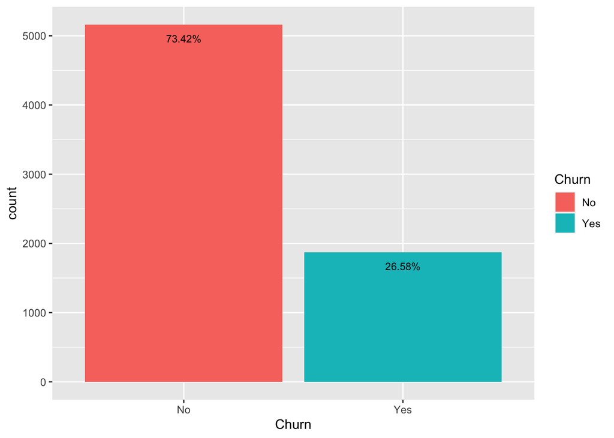

```r
# Churn distribution
p=ggplot(churn_clean, aes(x = Churn)) +
  geom_bar(aes(fill = Churn)) +
  geom_text(aes(y = ..count.. -200,
                label = paste0(round(prop.table(..count..),4) * 100, '%')),
            stat = 'count',
            position = position_dodge(.1),
            size = 3)
p
```

**Demografical Variable**

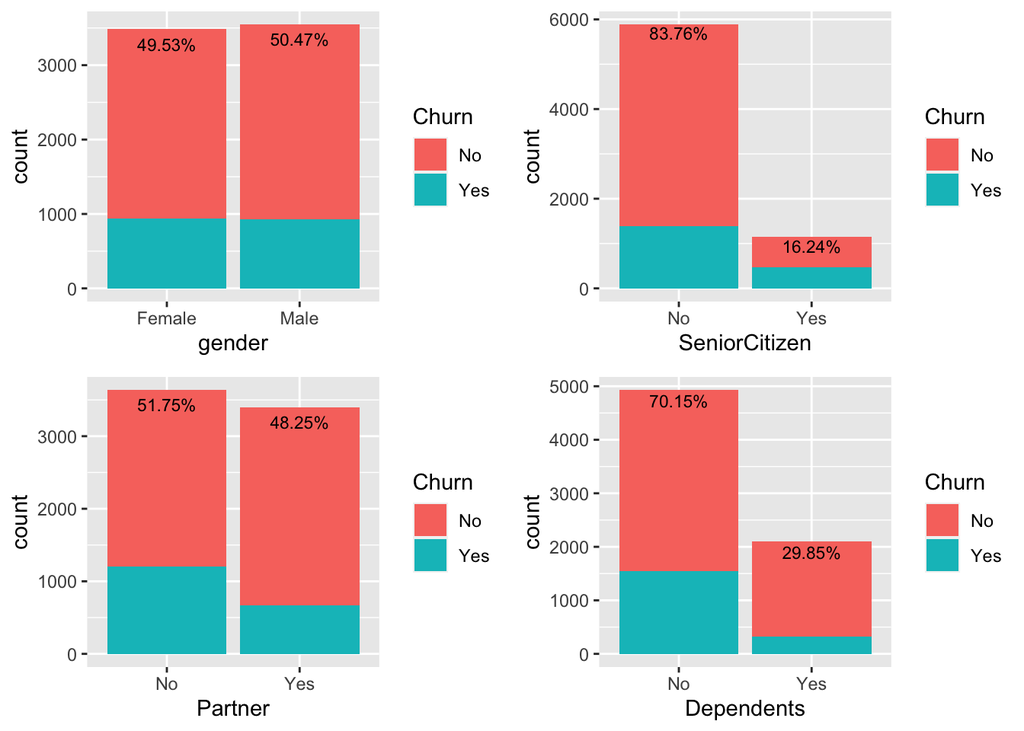

```r
#Gender plot
p1 <- ggplot(churn_clean, aes(x = gender)) +
  geom_bar(aes(fill = Churn)) +
  geom_text(aes(y = ..count.. -200,
                label = paste0(round(prop.table(..count..),4) * 100, '%')),
            stat = 'count',
            position = position_dodge(.1),
            size = 3)

#Senior citizen plot
p2 <- ggplot(churn_clean, aes(x = SeniorCitizen)) +
  geom_bar(aes(fill = Churn)) +
  geom_text(aes(y = ..count.. -200,
                label = paste0(round(prop.table(..count..),4) * 100, '%')),
            stat = 'count',
            position = position_dodge(.1),
            size = 3)

#Partner plot
p3 <- ggplot(churn_clean, aes(x = Partner)) +
  geom_bar(aes(fill = Churn)) +
  geom_text(aes(y = ..count.. -200,
                label = paste0(round(prop.table(..count..),4) * 100, '%')),
            stat = 'count',
            position = position_dodge(.1),
            size = 3)

#Dependents plot
p4 <- ggplot(churn_clean, aes(x = Dependents)) +
  geom_bar(aes(fill = Churn)) +
  geom_text(aes(y = ..count.. -200,
                label = paste0(round(prop.table(..count..),4) * 100, '%')),
            stat = 'count',
            position = position_dodge(.1),
            size = 3)

#Plot demographic data within a grid
grid.arrange(p1, p2, p3, p4, ncol=2)
```

**Some Categorical variables**

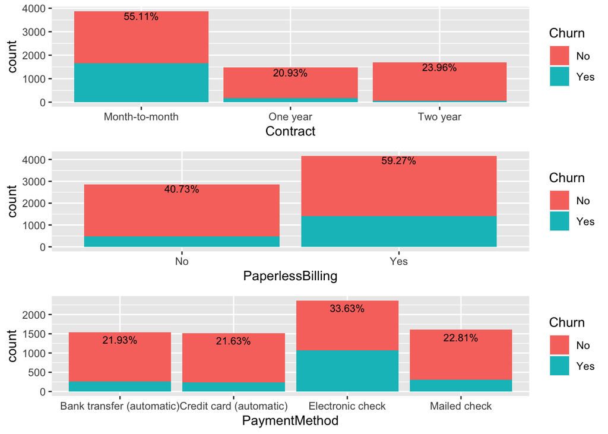

```r
#Contract status plot
p14 <- ggplot(churn_clean, aes(x = Contract)) +
  geom_bar(aes(fill = Churn)) +
  geom_text(aes(y = ..count.. -200,
                label = paste0(round(prop.table(..count..),4) * 100, '%')),
            stat = 'count',
            position = position_dodge(.1),
            size = 3)

#Paperless billing plot
p15 <- ggplot(churn_clean, aes(x = PaperlessBilling)) +
  geom_bar(aes(fill = Churn)) +
  geom_text(aes(y = ..count.. -200,
                label = paste0(round(prop.table(..count..),4) * 100, '%')),
            stat = 'count',
            position = position_dodge(.1),
            size = 3)

#Payment method plot
p16 <- ggplot(churn_clean, aes(x = PaymentMethod)) +
  geom_bar(aes(fill = Churn)) +
  geom_text(aes(y = ..count.. -200,
                label = paste0(round(prop.table(..count..),4) * 100, '%')),
            stat = 'count',
            position = position_dodge(.1),
            size = 3)

#Plot contract data within a grid
grid.arrange(p14, p15, p16, ncol=1)
```

**Numerical Variables**

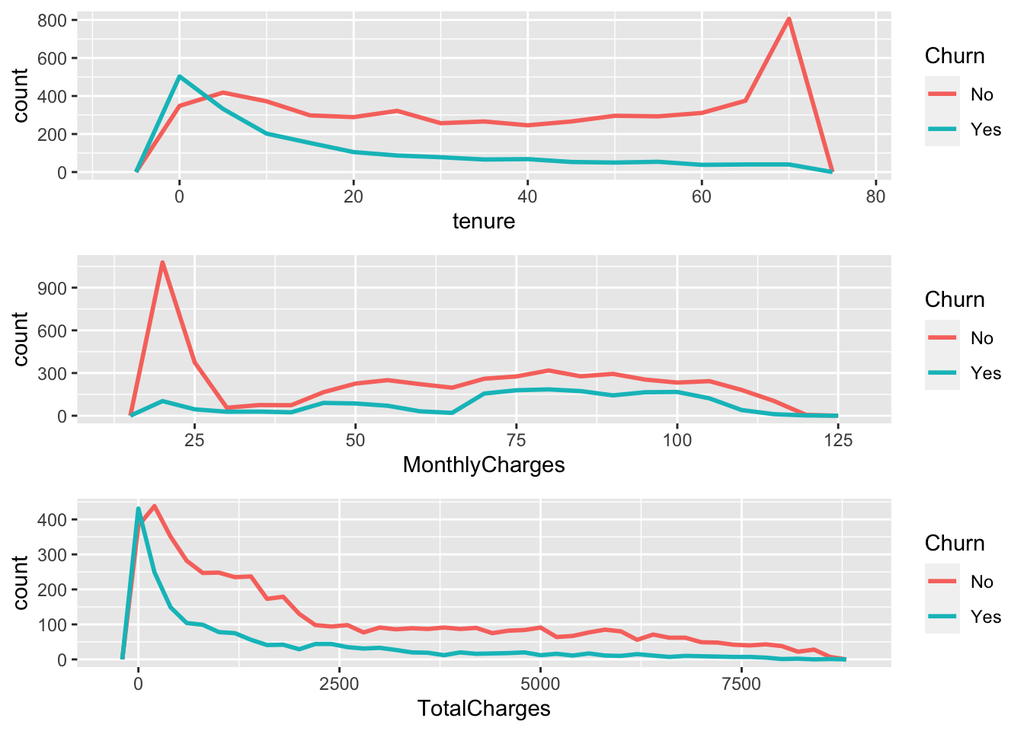

```r
#Tenure histogram
p17 <- ggplot(data = churn_clean, aes(tenure, color = Churn))+
  geom_freqpoly(binwidth = 5, size = 1)

#Monthly charges histogram
p18 <- ggplot(data = churn_clean, aes(MonthlyCharges, color = Churn))+
  geom_freqpoly(binwidth = 5, size = 1)

#Total charges histogram
p19 <- ggplot(data = churn_clean, aes(TotalCharges, color = Churn))+
  geom_freqpoly(binwidth = 200, size = 1)

#Plot quantitative data within a grid
grid.arrange(p17, p18, p19, ncol=1)
```

# Divide the dataset in training and test

```r
set.seed(123)
split_train_test <- createDataPartition(churn_clean$Churn,p=0.7,list=FALSE)
dtrain<- churn_clean[split_train_test,]
dtest<-  churn_clean[-split_train_test,]
```

# Logistic regression

```r
lr_fit <- glm(Churn ~., data = dtrain,
          family=binomial(link='logit'))
summary(lr_fit)
```

```
##
## Call:
## glm(formula = Churn ~ ., family = binomial(link = "logit"), data = dtrain)
##
## Deviance Residuals:
##     Min       1Q   Median       3Q      Max
## -1.8637  -0.6953  -0.2890   0.7553   3.2200
##
## Coefficients:
##                                        Estimate Std. Error z value Pr(>|z|)
## (Intercept)                           1.0746695  0.9571525   1.123 0.261532
## genderMale                           -0.0482269  0.0771304  -0.625 0.531797
## SeniorCitizenYes                      0.1200467  0.1014491   1.183 0.236683
## PartnerYes                           -0.0910761  0.0918164  -0.992 0.321228
## DependentsYes                        -0.0843260  0.1068161  -0.789 0.429849
## tenure                               -0.0621135  0.0074487  -8.339  < 2e-16 ***
## PhoneServiceYes                       0.0233358  0.7635434   0.031 0.975618
## MultipleLinesYes                      0.3794100  0.2078464   1.825 0.067935 .
## InternetServiceFiber optic            1.5613737  0.9372764   1.666 0.095741 .
## InternetServiceNo                    -1.5047493  0.9480893  -1.587 0.112481
## OnlineSecurityYes                    -0.2149292  0.2098780  -1.024 0.305804
## OnlineBackupYes                       0.0008494  0.2053088   0.004 0.996699
## DeviceProtectionYes                   0.1177891  0.2084585   0.565 0.572041
## TechSupportYes                       -0.1280168  0.2128673  -0.601 0.547579
## StreamingTVYes                        0.5187839  0.3819512   1.358 0.174386
## StreamingMoviesYes                    0.5783808  0.3840289   1.506 0.132045
## ContractOne year                     -0.8451411  0.1304035  -6.481 9.11e-11 ***
## ContractTwo year                     -1.4644194  0.2039949  -7.179 7.04e-13 ***
## PaperlessBillingYes                   0.3020753  0.0884590   3.415 0.000638 ***
## PaymentMethodCredit card (automatic) -0.0093796  0.1357499  -0.069 0.944914
## PaymentMethodElectronic check         0.2897469  0.1124649   2.576 0.009985 **
## PaymentMethodMailed check            -0.1002695  0.1367827  -0.733 0.463524
## MonthlyCharges                       -0.0336622  0.0372618  -0.903 0.366314
## TotalCharges                          0.0003653  0.0000844   4.328 1.50e-05 ***
## ---
## Signif. codes:  0 '***' 0.001 '**' 0.01 '*' 0.05 '.' 0.1 ' ' 1
##
## (Dispersion parameter for binomial family taken to be 1)
##
##     Null deviance: 5702.8  on 4923  degrees of freedom
## Residual deviance: 4117.1  on 4900  degrees of freedom
## AIC: 4165.1
##
## Number of Fisher Scoring iterations: 6
```

**Confusion Matrix**

```r
lr_prob1 <- predict(lr_fit, dtest, type="response")
lr_pred1 <- ifelse(lr_prob1 > 0.5,"Yes","No")
table(Predicted = lr_pred1, Actual = dtest$Churn)
```

```
##          Actual
## Predicted   No  Yes
##       No  1385  229
##       Yes  163  331
```

**Accuracy**

```r
lr_prob2 <- predict(lr_fit, dtrain, type="response")
lr_pred2 <- ifelse(lr_prob2 > 0.5,"Yes","No")
lr_tab1 <- table(Predicted = lr_pred2, Actual = dtrain$Churn)
lr_tab2 <- table(Predicted = lr_pred1, Actual = dtest$Churn)
```

```r
# Train
confusionMatrix(
  as.factor(lr_pred2),
  as.factor(dtrain$Churn),
  positive = "Yes"
)
```

```
## Confusion Matrix and Statistics
##
##           Reference
## Prediction   No  Yes
##        No  3237  598
##        Yes  378  711
##
##                Accuracy : 0.8018
##                  95% CI : (0.7904, 0.8128)
##     No Information Rate : 0.7342
##     P-Value [Acc > NIR] : < 2.2e-16
##
##                   Kappa : 0.4634
##
##  Mcnemar's Test P-Value : 2.383e-12
##
##             Sensitivity : 0.5432
##             Specificity : 0.8954
##          Pos Pred Value : 0.6529
##          Neg Pred Value : 0.8441
##              Prevalence : 0.2658
##          Detection Rate : 0.1444
##    Detection Prevalence : 0.2212
##       Balanced Accuracy : 0.7193
##
##        'Positive' Class : Yes
##
```

```r
# Test
confusionMatrix(
as.factor(lr_pred1),
  as.factor(dtest$Churn),
  positive = "Yes"
)
```

```
## Confusion Matrix and Statistics
##
##           Reference
## Prediction   No  Yes
##        No  1385  229
##        Yes  163  331
##
##                Accuracy : 0.814
##                  95% CI : (0.7968, 0.8304)
##     No Information Rate : 0.7343
##     P-Value [Acc > NIR] : < 2.2e-16
##
##                   Kappa : 0.5048
##
##  Mcnemar's Test P-Value : 0.001027
##
##             Sensitivity : 0.5911
##             Specificity : 0.8947
##          Pos Pred Value : 0.6700
##          Neg Pred Value : 0.8581
##              Prevalence : 0.2657
##          Detection Rate : 0.1570
##    Detection Prevalence : 0.2343
##       Balanced Accuracy : 0.7429
##
##        'Positive' Class : Yes
##
```

# ROC Curve

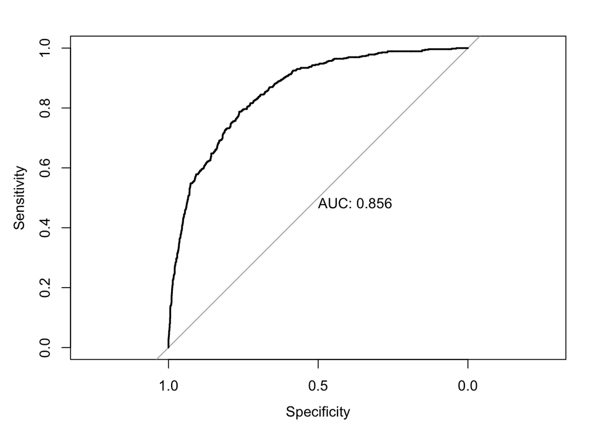

```r
library(pROC)
lr_prob2 <- predict(lr_fit, dtest, type="response")
test_roc = roc(dtest$Churn ~ lr_prob2, plot = TRUE, print.auc = TRUE)
```

```r
as.numeric(test_roc$auc)
```

```
## [1] 0.855544
```

# Relation with tenure

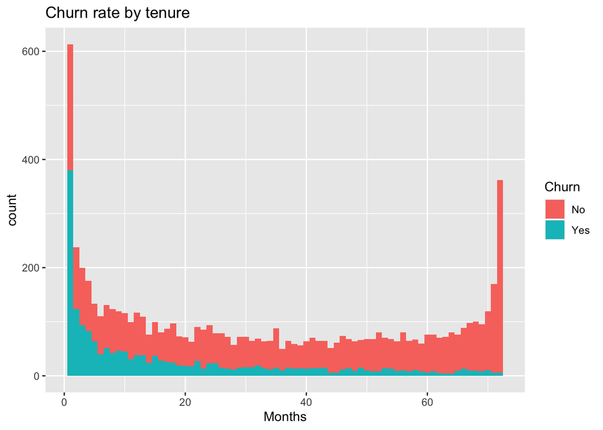

```r
p23 <- ggplot(churn_clean, aes(x = tenure, fill = Churn)) +
  geom_histogram(binwidth = 1) +
  labs(x = "Months",
       title = "Churn rate by tenure")
p23
```

# Relation with Total Charges

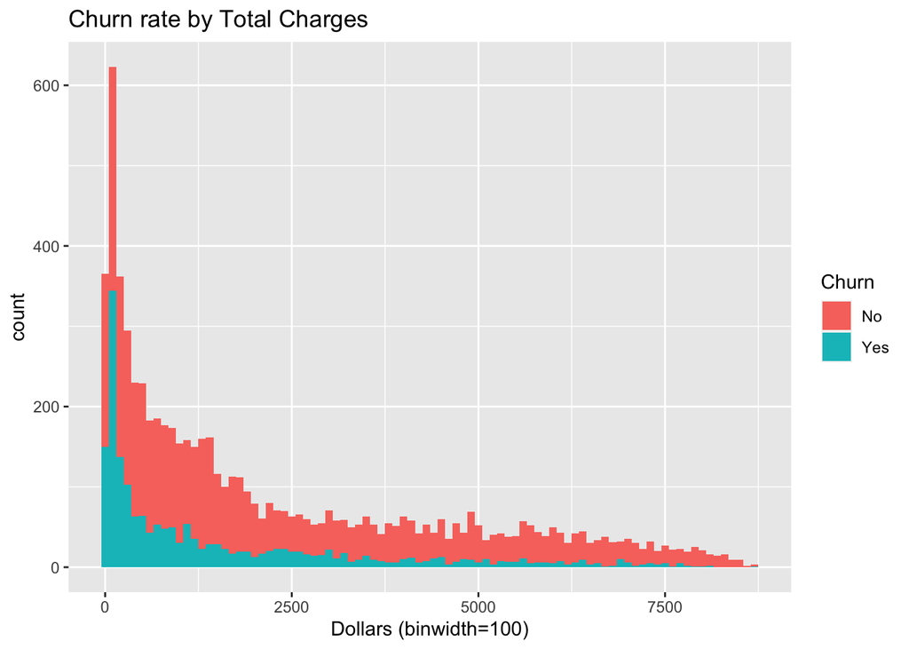

```r
p24 <- ggplot(churn_clean, aes(x = TotalCharges, fill = Churn)) +
  geom_histogram(binwidth = 100) +
  labs(x = "Dollars (binwidth=100)",
       title = "Churn rate by Total Charges")
p24
```

# Linear Discriminant Analysis

```r
library(MASS)
lda.fit=lda(Churn~.,data = dtrain)
lda.fit
```

```
## Call:
## lda(Churn ~ ., data = dtrain)
##
## Prior probabilities of groups:
##        No       Yes
## 0.7341592 0.2658408
##
## Group means:
##     genderMale SeniorCitizenYes PartnerYes DependentsYes   tenure
## No   0.5189488        0.1347165  0.5278008     0.3369295 37.73693
## Yes  0.5019099        0.2452254  0.3544691     0.1772345 18.24370
##     PhoneServiceYes MultipleLinesYes InternetServiceFiber optic
## No        0.9029046        0.4149378                  0.3532503
## Yes       0.9136746        0.4576012                  0.6913675
##     InternetServiceNo OnlineSecurityYes OnlineBackupYes DeviceProtectionYes
## No         0.27302905         0.3319502       0.3698479           0.3643154
## Yes        0.06493506         0.1634836       0.2826585           0.2948816
##     TechSupportYes StreamingTVYes StreamingMoviesYes ContractOne year
## No       0.3300138      0.3656985          0.3687414       0.25172891
## Yes      0.1764706      0.4430863          0.4430863       0.08250573
##     ContractTwo year PaperlessBillingYes PaymentMethodCredit card (automatic)
## No        0.31811895           0.5278008                            0.2426003
## Yes       0.02826585           0.7394958                            0.1275783
##     PaymentMethodElectronic check PaymentMethodMailed check MonthlyCharges
## No                      0.2542185                 0.2525588       61.44945
## Yes                     0.5653170                 0.1680672       74.63789
##     TotalCharges
## No      2557.961
## Yes     1564.177
##
## Coefficients of linear discriminants:
##                                                LD1
## genderMale                           -0.0333717048
## SeniorCitizenYes                      0.1450891498
## PartnerYes                           -0.0576700123
## DependentsYes                        -0.0664815653
## tenure                               -0.0099856247
## PhoneServiceYes                      -0.0891893418
## MultipleLinesYes                      0.2604920859
## InternetServiceFiber optic            0.9803760743
## InternetServiceNo                    -0.7405253035
## OnlineSecurityYes                    -0.2199831092
## OnlineBackupYes                      -0.0620840218
## DeviceProtectionYes                   0.0035981690
## TechSupportYes                       -0.1749447445
## StreamingTVYes                        0.2715875113
## StreamingMoviesYes                    0.3381568234
## ContractOne year                     -0.6433890801
## ContractTwo year                     -0.4589375262
## PaperlessBillingYes                   0.2088494166
## PaymentMethodCredit card (automatic)  0.0075669672
## PaymentMethodElectronic check         0.3247593439
## PaymentMethodMailed check            -0.0661656714
## MonthlyCharges                       -0.0035819843
## TotalCharges                         -0.0002132643
```

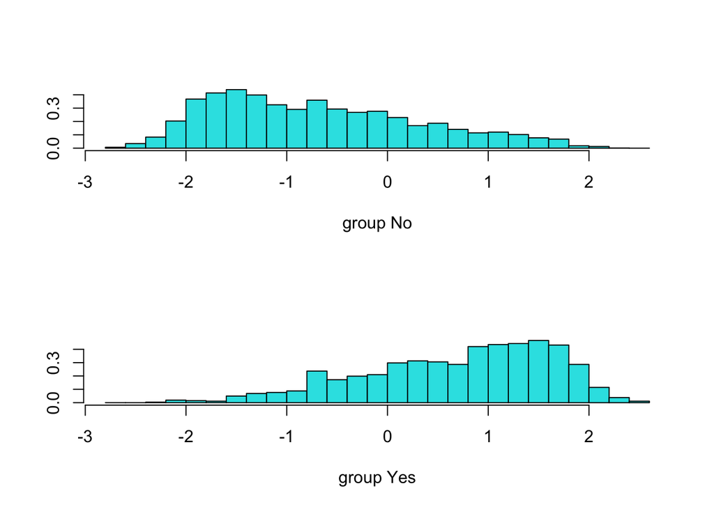

```r
plot(lda.fit)
```

```r
lda.pred=predict(lda.fit,dtest)$class
table(lda.pred,dtest$Churn)
```

```
##
## lda.pred   No  Yes
##      No  1369  241
##      Yes  179  319
```

```r
mean(lda.pred==dtest$Churn)
```

```
## [1] 0.800759
```